# Predictive Classification - Dumbell Lift Method

Scott Dayer

5/23/2019

## Executive Summary

This report describes the process and analysis performed to build a model that accurately predicts the method (“classe”) in which a dumbell is raised from the Weight Lifting Exercise Dataset.

Six young health participants were asked to perform one set of 10 repetitions of the Unilateral Dumbbell Biceps Curl in five different fashions:

1. exactly according to the specification
2. throwing the elbows to the front
3. lifting the dumbbell only halfway
4. lowering the dumbbell only halfway
5. throwing the hips to the front

After exploratory data analysis is conducted, and pre-processing strategies are identified, several models are constructed and analyzed on a validation set of data, and a final model is selected for optimal accuracy and processing speed for use on the test data in order to submit the course quiz.

The selected model utilizes k-folds cross validation and a random forest machine learning algorithm. **The 95% confidence interval for accurately identifying the correct “classe” is 99.48 to 99.94%.**

```r
library(tidyverse)
library(caret)
library(doParallel)
library(corrplot)

training <- as_tibble(read.csv(url("https://d396qusza40orc.cloudfront.net/predmachlearn/pml-training.csv")))
testing <- as_tibble(read.csv(url("https://d396qusza40orc.cloudfront.net/predmachlearn/pml-testing.csv")))

set.seed(10)
```

## Exploratory Data Analysis and Data Prep

First, I look at the numbr of variables and amount of data in the training data set.

```r
print(dim(training))
```

```
## [1] 19622   160
```

With nearly 20,000 records and 160 variables, I eliminate some of the variables to remove data issues that might impact the ability to run models, and also to simplify analysis and interpretability.

I identify a number of variables with very low variance where the most common value is more than 20 times more frequent than the next most common value and percentage of distinct values out of the number of total samples is less than 10.  
I also identify a number of variables with mostly (19216 out of 19622) NA values that can be removed from the dataset.

```r
# count number of NAs for each variable
na_count <- sapply(training, function(y) sum(length(which(is.na(y)))))
na_count <- data.frame(na_count)

#identify the variables with near zero variance
# to eliminate certain variables that
nzv <- nearZeroVar(training)

#remove all variable with near zero variance
trainingNNZV <- training[,-c(nzv)]

#remove all variables with NAs
training2 <- trainingNNZV[,colSums(is.na(trainingNNZV)) < 15000]
t <- training2[,6:59]
```

#### Validation data set

Next, I create a validation data set from the training data set in order to compare various models’ accuracy prior to using on the quiz test set.

```r
# create a validation set from training set
inTrain <- createDataPartition(t$classe, p = .9, list = FALSE)
trainSet <- t[inTrain,]
validationSet <- t[-inTrain,]
```

#### Pair-wise correlation

I then explore correlations among preditors. While many of the variables show litlte correlation, there are also many pairs with high levels of correlation. This is addressed by preprocessing with principal component analysis in construction of the prediction models.

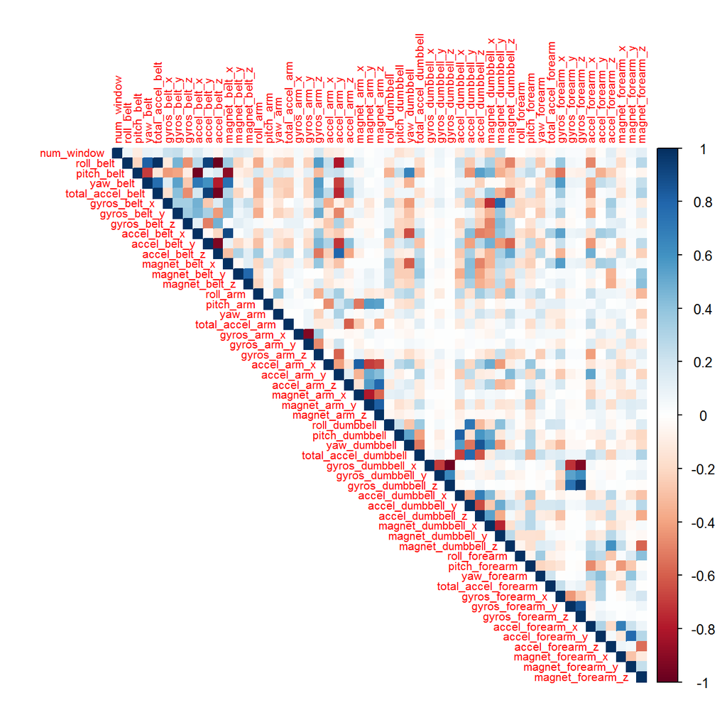

```r
mat <- trainSet[1:length(trainSet)-1]
mat <- round(cor(mat),2)

corrplot(mat, method = "color", type = "upper", order = "original", tl.cex = .65)
```

## Model construction, validation and selection

#### Model 3 - rfcv7

This model removes the pre-processing of model 2, and increases k-folds from model 1 from 3 to 7. Run time increases by 3X without significant performance improvement over model 1.

#### Model 4 - gbm

```r
cluster <- makeCluster(detectCores() - 1) # convention to leave 1 core for OS
registerDoParallel(cluster)

# k-folds parameters
kf3 <- trainControl(method = "cv", number = 3)
kf7 <- trainControl(method = "cv", number = 7)

preAll <- Sys.time()

# model 1
model_rfnp <- train(classe ~ .,
                    method = "rf",
                    data = trainSet,
                    trControl = kf3,
                    allowParallel = TRUE)
postrfnp <- Sys.time()

# model 2
model_rfpp <- train(classe ~ .,
                    method = "rf",
                    data = trainSet,
                    preProcess = c("center", "scale", "pca"),
                    trControl = kf3,
                    allowParallel = TRUE)
postrfpp <- Sys.time()

# model 3
model_rfcv7 <- train(classe ~ .,
                     method = "rf",
                     data = trainSet,
                     trControl = kf7,
                     allowParallel = TRUE)
post_rfcv7 <- Sys.time()

# model 4
model_gbm <- train(classe ~ .,
                     method = "gbm",
                     data = trainSet,
                     preProcess = "pca",
                     trControl = kf3,
                     verbose = FALSE)
post_gbm <- Sys.time()

stopCluster(cluster)
registerDoSEQ()
```

The prediction accuracy on the validation data set and time to train the model on the training data set is compared in the table below.

```r
# model 1
pred_rfnp <- predict(model_rfnp, validationSet)
vacc_rfnp <- mean(pred_rfnp == validationSet$classe)

# model 2
pred_rfpp <- predict(model_rfpp, validationSet)
vacc_rfpp <- mean(pred_rfpp == validationSet$classe)

# model 3
pred_rfcv7 <- predict(model_rfcv7, validationSet)
vacc_rfcv7 <- mean(pred_rfcv7 == validationSet$classe)

# model 4
pred_gbm <- predict(model_gbm, validationSet)
vacc_gbm <- mean(pred_gbm == validationSet$classe)

# building simple table of run times and accuracy
mod_compare <- enframe(c(rfnp = postrfnp-preAll,
                   rfpp = postrfpp-postrfnp,
                   rfcv7 = post_rfcv7-postrfpp,
                   gbm=post_gbm-post_rfcv7)) %>%
        add_column(val_mod_acc = c(vacc_rfnp,
                                   vacc_rfpp,
                                   vacc_rfcv7,
                                   vacc_gbm)) %>%
        rename(model = name, time = value)

print(mod_compare)
```

```
## # A tibble: 4 x 3
##   model time           val_mod_acc
##   <chr> <time>               <dbl>
## 1 rfnp   6.908613 mins       0.998
## 2 rfpp   3.431303 mins       0.987
## 3 rfcv7 20.386930 mins       0.998
## 4 gbm    1.634983 mins       0.830
```

## Model selection and findings

Below is a confusion matrix for the top performing model, Model 1 (rfnp), in terms of time to train the model and accuracy of prediction on the validation data set.

```r
confusionMatrix(pred_rfnp, validationSet$classe)
```

```
## Confusion Matrix and Statistics
##
##           Reference
## Prediction   A   B   C   D   E
##          A 558   0   0   0   0
##          B   0 379   2   0   0
##          C   0   0 340   1   0
##          D   0   0   0 320   1
##          E   0   0   0   0 359
##
## Overall Statistics
##
##                Accuracy : 0.998
##                  95% CI : (0.9948, 0.9994)
##     No Information Rate : 0.2847
##     P-Value [Acc > NIR] : < 2.2e-16
##
##                   Kappa : 0.9974
##
##  Mcnemar's Test P-Value : NA
##
## Statistics by Class:
##
##                      Class: A Class: B Class: C Class: D Class: E
## Sensitivity            1.0000   1.0000   0.9942   0.9969   0.9972
## Specificity            1.0000   0.9987   0.9994   0.9994   1.0000
## Pos Pred Value         1.0000   0.9948   0.9971   0.9969   1.0000
## Neg Pred Value         1.0000   1.0000   0.9988   0.9994   0.9994
## Prevalence             0.2847   0.1934   0.1745   0.1638   0.1837
## Detection Rate         0.2847   0.1934   0.1735   0.1633   0.1832
## Detection Prevalence   0.2847   0.1944   0.1740   0.1638   0.1832
## Balanced Accuracy      1.0000   0.9994   0.9968   0.9981   0.9986
```

I found that pre-processing does appear to be reducing complexity and runtime but at a cost to accuracy. Extra k-folds does not appear to significantly increase performance given the extra processing time based on the other implementation decisions I have made.

Given the level of accuracy in Model 1 (rfnp) and reasonable run time, this model is selected for use on the testing data set for use in the course quiz.

## Prediction quiz

```r
pred_rfnp_quiz <- predict(model_rfnp, testing)

quizTable <- enframe(pred_rfnp_quiz, name = "QuizQ", value = "Prediction")

quizTable
```

```
## # A tibble: 20 x 2
##    QuizQ Prediction
##    <int> <fct>
##  1     1 B
##  2     2 A
##  3     3 B
##  4     4 A
##  5     5 A
##  6     6 E
##  7     7 D
##  8     8 B
##  9     9 A
## 10    10 A
## 11    11 B
## 12    12 C
## 13    13 B
## 14    14 A
## 15    15 E
## 16    16 E
## 17    17 A
## 18    18 B
## 19    19 B
## 20    20 B
```